# IST 718: Big Data Analytics

- Professor: Daniel Acuna deacuna@syr.edu

## General instructions:

- You are welcome to discuss the problems with your classmates but **you are not allowed to copy any part of your answers either from your classmates or from the internet**
- You can put the homework files anywhere you want in your http://notebook.acuna.io workspace but *do not change* the file names. The TAs and the professor use these names to grade your homework.
- Remove or comment out code that contains `raise NotImplementedError`. This is mainly to make the `assert` statement fail if nothing is submitted.
- The tests shown in some cells (i.e., `assert` and `np.testing.` statements) are used to grade your answers. **However, the professor and TAs will use **additional** test for your answer. Think about cases where your code should run even if it passess all the tests you see.**
- Before downloading and submitting your work through Blackboard, remember to save and press `Validate` (or go to `Kernel`$\rightarrow$`Restart and Run All`).
- Good luck!

```python
# Load the packages needed for this part
# create spark and sparkcontext objects
from pyspark.sql import SparkSession
import numpy as np

spark = SparkSession.builder.getOrCreate()
sc = spark.sparkContext

import pyspark
from pyspark.ml import feature, regression, Pipeline
from pyspark.sql import functions as fn, Row
from pyspark import sql

import matplotlib.pyplot as plt
import pandas as pd
```

# Part 1: Servo analysis

In this assignment, you will continue the analysis we started in class of the Servo dataset.

# Servo data analysis

```
1. Title: Servo Data

2. Sources
   (a) Created by: Karl Ulrich (MIT) in 1986
   (b) Donor: Ross Quinlan
   (c) Date: May 1993

3. Past Usage:

   1.  Quinlan, J.R., "Learning with continuous classes", Proc. 5th Australian
       Joint Conference on AI (eds A. Adams and L. Sterling), Singapore: World
       Scientific, 1992

   2.  Quinlan, J.R., "Combining instance-based and model-based learning",
       Proc. ML'93 (ed P.E. Utgoff), San Mateo: Morgan Kaufmann 1993

       Results on 10-way cross-validation:

       Method           Average     Relative
       ------            |Err|       Error
                -------     --------

       Guessing mean          1.15        1.00
       Instance-based          .52         .26
       Regression          .86         .49
       Model trees         .45         .29
       Neural nets (G. Hinton)     .30         .11
       Regression+instances    .48         .20
       Model trees+instances       .30         .17
       NN+instances        .29         .11

4. Relevant Information:

   Ross Quinlan:

   This data was given to me by Karl Ulrich at MIT in 1986.  I didn't
   record his description at the time, but here's his subsequent (1992)
   recollection:

     "I seem to remember that the data was from a simulation of a servo
     system involving a servo amplifier, a motor, a lead screw/nut, and a
     sliding carriage of some sort.  It may have been on of the
     translational axes of a robot on the 9th floor of the AI lab.  In any
     case, the output value is almost certainly a rise time, or the time
     required for the system to respond to a step change in a position set
     point."

   (Quinlan, ML'93)

   "This is an interesting collection of data provided by Karl
    Ulrich.  It covers an extremely non-linear phenomenon - predicting the
    rise time of a servomechanism in terms of two (continuous) gain settings
    and two (discrete) choices of mechanical linkages."

5. Number of Instances: 167

6. Number of Attributes: 4 + numeric class attribute

7. Attribute information:

   1. motor: A,B,C,D,E
   2. screw: A,B,C,D,E
   3. pgain: 3,4,5,6
   4. vgain: 1,2,3,4,5
   5. class: 0.13 to 7.10

8. Missing Attribute Values: None
```

```python
# Load the data
servo_df = spark.createDataFrame(pd.read_csv('/datasets/servo.data',
            sep=',',
            header=None,
            names=['motor', 'screw', 'pgain', 'vgain', 'rise_time']))
```

# 1. Explore the data

With big data, datasets can be too big to bring them into the Spark client. However, we can use the `limit` method of a dataframe to limit the number of rows to bring as a Pandas dataframe

Create a dataframe `servo_sample_df` with the first 20 rows of `servo_df`

```python
# create `servo_sample_df`
servo_sample_df = servo_df.limit(20)
```

```python
# 2 pts - right number of rows
np.testing.assert_equal(servo_sample_df.count(), 20)
```

**(3 pts)** Below, transform `servo_sample_df` into a Pandas dataframe and do a scatter plot of `pgain` vs `rise_time`

```
   motor screw  pgain  vgain  rise_time
0      E     E      5      4   0.281251
1      B     D      6      5   0.506252
2      D     D      4      3   0.356251
3      B     A      3      2   5.500033
4      D     B      6      5   0.356251
5      E     C      4      3   0.806255
6      C     A      3      2   5.100014
7      A     A      3      2   5.700042
8      C     A      6      5   0.768754
9      D     A      4      1   1.031254
10     B     E      6      5   0.468752
11     E     C      5      4   0.393752
12     B     C      4      1   0.281251
13     E     C      3      1   1.100000
14     C     C      5      4   0.506252
15     E     B      3      2   1.899990
16     D     C      3      1   0.900001
17     B     C      5      4   0.468752
18     B     B      5      4   0.543753
19     C     E      4      2   0.206250
```

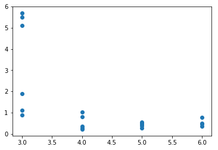

```python
servo_sample_df_pd = servo_sample_df.toPandas()
print(servo_sample_df_pd)
plt.scatter(servo_sample_df_pd.pgain, servo_sample_df_pd.rise_time)
```

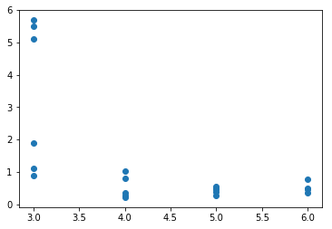

```python
servo_sample_df_pd = servo_sample_df.toPandas()
plt.scatter(servo_sample_df_pd.pgain, servo_sample_df_pd.rise_time)
```

## Perform correlations between vgain-rise time, pgain-rise time, and vgain-pgain

Create a `servo_corr_df` dataframe that contains the correlations between `vgain` and `rise_time` as a column `corr_vgain_rise_time`, between `pgain` and `rise_time` as `corr_pgain_rise_time`, and `vgain` and `pgain` as `corr_vgain_pgain`.

```python
# create `servo_corr_df` here
from pyspark.ml.stat import Correlation

## 1. pandas

servo_df_pd = servo_df.toPandas()

corr_vgain_rise_time = servo_df_pd['vgain'].corr(servo_df_pd['rise_time'])

corr_pgain_rise_time = servo_df_pd['pgain'].corr(servo_df_pd['rise_time'])

corr_vgain_pgain = servo_df_pd['vgain'].corr(servo_df_pd['pgain'])

servo_corr_df_pd = pd.DataFrame({'corr_vgain_rise_time':[corr_vgain_rise_time],
                    'corr_pgain_rise_time':[corr_pgain_rise_time],
                    'corr_vgain_pgain':[corr_vgain_pgain]})

print(servo_corr_df_pd)

## 2. PySpark

corr_vgain_rise_time = servo_df.stat.corr("vgain", "rise_time")
corr_pgain_rise_time = servo_df.stat.corr("pgain", "rise_time")
corr_vgain_pgain = servo_df.stat.corr("vgain", "pgain")

data1 = [(corr_vgain_rise_time, corr_pgain_rise_time, corr_vgain_pgain)]

servo_corr_df = spark.createDataFrame(data1)
servo_corr_df = servo_corr_df.selectExpr("_1 as corr_vgain_rise_time", "_2 as corr_pgain_rise_time", "_3 as corr_vgain_pgain")
servo_corr_df.show()
```

```
   corr_vgain_rise_time  corr_pgain_rise_time  corr_vgain_pgain
0             -0.364383             -0.598129          0.812268
+--------------------+--------------------+------------------+
|corr_vgain_rise_time|corr_pgain_rise_time|  corr_vgain_pgain|
+--------------------+--------------------+------------------+
|-0.36438266626914606| -0.5981287119612232|0.8122683058183874|
+--------------------+--------------------+------------------+
```

```python
## 7 pts
np.testing.assert_equal(set(servo_corr_df.columns),
                        {'corr_pgain_rise_time', 'corr_vgain_pgain', 'corr_vgain_rise_time'})
np.testing.assert_almost_equal(list(servo_corr_df.first().asDict().values()),
                               [-0.36438266626914595, -0.5981287119612234, 0.8122683058183874], decimal=3)
```

## Compute mean rise_time for different motors and screws

Create `motor_rise_time_df` with the column `motor` and `avg_rise_time`, where `avg_rise_time` is the average rise time for a motor. Sort the resulting dataframe from highest to lowest average rise time.

```python
## 1. Pandas
motor_rise_time_df1 = servo_df_pd.groupby('motor')['rise_time'].mean()
motor_rise_time_df1.columns = ['motor','avg_rise_time']
print(motor_rise_time_df1)

## 2. PySpark
from pyspark.sql.functions import col

motor_rise_time_df = servo_df.groupBy('motor').agg(fn.avg('rise_time').alias("avg_rise_time")).sort(col("avg_rise_time").desc())
motor_rise_time_df.show()
```

```
motor
A    1.761111
B    1.681942
C    1.254061
D    0.917613
E    1.144893
Name: rise_time, dtype: float64
+-----+------------------+
|motor|     avg_rise_time|
+-----+------------------+
|    A| 1.761110668888889|
|    B|1.6819423677777776|
|    C|1.2540610067499998|
|    E| 1.144893208181818|
|    D|0.9176125145454546|
+-----+------------------+
```

```python
# 3 pts
np.testing.assert_array_almost_equal(
    (motor_rise_time_df.orderBy('motor').select('avg_rise_time').\
     rdd.map(lambda x: list(x.asDict().values())).collect())
    ,
[[1.761110668888889],
 [1.6819423677777776],
 [1.2540610067499998],
 [0.9176125145454546],
 [1.144893208181818]], decimal=3)
```

Create `screw_rise_time_df` with the column `screw` and `avg_rise_time` sorted from highest to lowest average rise time.

```python
# YOUR CODE HERE

# 1. pandas
screw_rise_time_df1 = servo_sample_df_pd.groupby('screw')['rise_time'].mean()
print(screw_rise_time_df1)

#2. pyspark
screw_rise_time_df = servo_df.groupBy('screw').agg(fn.avg('rise_time').alias("avg_rise_time")).sort(col("avg_rise_time").desc())

screw_rise_time_df.show()
```

```
screw
A    3.620019
B    0.933331
C    0.636609
D    0.431252
E    0.318751
Name: rise_time, dtype: float64
+-----+------------------+
|screw|     avg_rise_time|
+-----+------------------+
|    A| 1.768461212142857|
|    B|1.3919625091428571|
|    C|1.2485862280645161|
|    E| 1.225643291724138|
|    D|1.1612471173333332|
+-----+------------------+
```

```python
# 3 pts
np.testing.assert_array_almost_equal(
    (screw_rise_time_df.orderBy('screw').select('avg_rise_time').\
     rdd.map(lambda x: list(x.asDict().values())).collect())
    ,
       [[1.768461212142857],
 [1.3919625091428571],
 [1.2485862280645161],
 [1.1612471173333332],
 [1.225643291724138]],
decimal=3)
```

# Feature engineering

## Dummy variables for motors and screws

Create a dataframe `dummy_df` with columns `motor` and `screw` as dummy variables, and columns `vgain`, `pgain`, and `rise_time`. Use motor D and screw C as the baselines and name the dummy variables `motor_A` for motor `A` and so on. Follow a similar pattern for screw. The dataframe `dummy_df` should not contain the columns `motor` and `screw` but only their dummy variable representations. **All column types should be float or integer.**

```python
# create dummy_df below
motor = servo_df.select("motor").distinct().rdd.flatMap(lambda x: x).collect()
screw = servo_df.select("screw").distinct().rdd.flatMap(lambda x: x).collect()

motor_expr = [fn.when(fn.col("motor") == i, 1).otherwise(0).alias("motor_" + i) for i in motor]

screw_expr = [fn.when(fn.col("screw") == j, 1).otherwise(0).alias("screw_" + j) for j in screw]

dummy_df = servo_df.select("vgain", "pgain", "rise_time", *motor_expr+screw_expr)
dummy_df = dummy_df.drop('motor_D')
dummy_df = dummy_df.drop('screw_C')
dummy_df = dummy_df.select(*(fn.col(c).cast("float").alias(c) for c in dummy_df.columns))
dummy_df.show()
```

```
+-----+-----+----------+-------+-------+-------+-------+-------+-------+-------+-------+
|vgain|pgain| rise_time|motor_E|motor_B|motor_C|motor_A|screw_E|screw_B|screw_D|screw_A|
+-----+-----+----------+-------+-------+-------+-------+-------+-------+-------+-------+
|  4.0|  5.0|0.28125095|    1.0|    0.0|    0.0|    0.0|    1.0|    0.0|    0.0|    0.0|
|  5.0|  6.0| 0.5062525|    0.0|    1.0|    0.0|    0.0|    0.0|    0.0|    1.0|    0.0|
|  3.0|  4.0|0.35625148|    0.0|    0.0|    0.0|    0.0|    0.0|    0.0|    1.0|    0.0|
|  2.0|  3.0|  5.500033|    0.0|    1.0|    0.0|    0.0|    0.0|    0.0|    0.0|    1.0|
|  5.0|  6.0|0.35625148|    0.0|    0.0|    0.0|    0.0|    0.0|    1.0|    0.0|    0.0|
|  3.0|  4.0| 0.8062546|    1.0|    0.0|    0.0|    0.0|    0.0|    0.0|    0.0|    0.0|
|  2.0|  3.0|  5.100014|    0.0|    0.0|    1.0|    0.0|    0.0|    0.0|    0.0|    1.0|
|  2.0|  3.0| 5.7000422|    0.0|    0.0|    0.0|    1.0|    0.0|    0.0|    0.0|    1.0|
|  5.0|  6.0|0.76875436|    0.0|    0.0|    1.0|    0.0|    0.0|    0.0|    0.0|    1.0|
|  1.0|  4.0| 1.0312537|    0.0|    0.0|    0.0|    0.0|    0.0|    0.0|    0.0|    1.0|
|  5.0|  6.0|0.46875226|    0.0|    1.0|    0.0|    0.0|    1.0|    0.0|    0.0|    0.0|
|  4.0|  5.0|0.39375174|    1.0|    0.0|    0.0|    0.0|    0.0|    0.0|    0.0|    0.0|
|  1.0|  4.0|0.28125095|    0.0|    1.0|    0.0|    0.0|    0.0|    0.0|    0.0|    0.0|
|  1.0|  3.0|       1.1|    1.0|    0.0|    0.0|    0.0|    0.0|    0.0|    0.0|    0.0|
|  4.0|  5.0| 0.5062525|    0.0|    0.0|    1.0|    0.0|    0.0|    0.0|    0.0|    0.0|
|  2.0|  3.0| 1.8999897|    1.0|    0.0|    0.0|    0.0|    0.0|    1.0|    0.0|    0.0|
|  1.0|  3.0| 0.9000011|    0.0|    0.0|    0.0|    0.0|    0.0|    0.0|    0.0|    0.0|
|  4.0|  5.0|0.46875226|    0.0|    1.0|    0.0|    0.0|    0.0|    0.0|    0.0|    0.0|
|  4.0|  5.0| 0.5437528|    0.0|    1.0|    0.0|    0.0|    0.0|    1.0|    0.0|    0.0|
|  2.0|  4.0|0.20625044|    0.0|    0.0|    1.0|    0.0|    1.0|    0.0|    0.0|    0.0|
+-----+-----+----------+-------+-------+-------+-------+-------+-------+-------+-------+
only showing top 20 rows
```

```python
# 3 pts
np.testing.assert_equal(len(dummy_df.columns), 11)
np.testing.assert_equal(dummy_df.select(fn.sum('motor_A')).first()['sum(motor_A)'], 36)
np.testing.assert_equal(dummy_df.select(fn.sum('screw_A')).first()['sum(screw_A)'], 42)
```

# Model comparison

In the next set of questions, you will use the splits below to fit, validate, and estimate the generalization error of your models. The `randomSplit` is called with a seed so that it does not change from what the professor used.

```python
training_df, validation_df, testing_df = dummy_df.randomSplit([0.6, 0.3, 0.1], seed=0)
print("# points in training: ", training_df.count())
print("# points in validation: ", validation_df.count())
print("# points in testing: ", testing_df.count())
```

```
# points in training:  102
# points in validation:  50
# points in testing:  15
```

## Propose three regression models

In the next section, you will choose the best model to explain the data in `servo_df`. Select the right split of the data for the right step of the process (i.e., training, validation, and testing)

### Model 1: Fit model with only `pgain`

Create a pipeline that takes *pgain* as a feature to predict *rise time* and fits a linear regression model. You should start your pipeline by taking the appropriate column or columns from `dummy_df` in which the raw feature `pgain` may or may not have been feature engineered. Assign the fit pipeline transformer to `pipe_model1`. Your pipeline must have one vector assembler followed by a linear regression.

```python
training_df
```

```
DataFrame[vgain: float, pgain: float, rise_time: float, motor_E: float, motor_B: float, motor_C: float, motor_A: float, screw_E: float, screw_B: float, screw_D: float, screw_A: float]
```

```python
# create `pipe_model1` below

va = feature.VectorAssembler(inputCols=['pgain'], outputCol='features')

lr = regression.LinearRegression(featuresCol='features', labelCol='rise_time')

pipe = Pipeline(stages=[va, lr])

pipe_model1 = pipe.fit(training_df)

prediction1_df = pipe_model1.transform(validation_df)

prediction1_df.show()
```

```
+-----+-----+----------+-------+-------+-------+-------+-------+-------+-------+-------+--------+--------------------+
|vgain|pgain| rise_time|motor_E|motor_B|motor_C|motor_A|screw_E|screw_B|screw_D|screw_A|features|          prediction|
+-----+-----+----------+-------+-------+-------+-------+-------+-------+-------+-------+--------+--------------------+
|  1.0|  3.0| 0.5000003|    0.0|    0.0|    0.0|    0.0|    1.0|    0.0|    0.0|    0.0|   [3.0]|   2.226360313699868|
|  1.0|  3.0|       1.1|    1.0|    0.0|    0.0|    0.0|    0.0|    0.0|    0.0|    0.0|   [3.0]|   2.226360313699868|
|  1.0|  3.0|  3.899964|    0.0|    1.0|    0.0|    0.0|    0.0|    0.0|    0.0|    0.0|   [3.0]|   2.226360313699868|
|  1.0|  3.0| 7.1001077|    1.0|    0.0|    0.0|    0.0|    0.0|    0.0|    0.0|    1.0|   [3.0]|   2.226360313699868|
|  2.0|  3.0|       1.1|    1.0|    0.0|    0.0|    0.0|    1.0|    0.0|    0.0|    0.0|   [3.0]|   2.226360313699868|
|  2.0|  3.0| 1.8999897|    0.0|    0.0|    1.0|    0.0|    0.0|    0.0|    1.0|    0.0|   [3.0]|   2.226360313699868|
|  2.0|  3.0|  4.299977|    0.0|    1.0|    0.0|    0.0|    0.0|    1.0|    0.0|    0.0|   [3.0]|   2.226360313699868|
|  2.0|  3.0| 5.7000422|    0.0|    0.0|    0.0|    1.0|    0.0|    0.0|    0.0|    1.0|   [3.0]|   2.226360313699868|
|  2.0|  3.0| 6.9000983|    1.0|    0.0|    0.0|    0.0|    0.0|    0.0|    0.0|    1.0|   [3.0]|   2.226360313699868|
|  2.0|  4.0| 0.7312541|    0.0|    1.0|    0.0|    0.0|    0.0|    1.0|    0.0|    0.0|   [4.0]|  1.4324468112147821|
|  2.0|  5.0| 0.5437528|    0.0|    0.0|    1.0|    0.0|    0.0|    0.0|    0.0|    1.0|   [5.0]|  0.6385333087296963|
|  2.0|  6.0| 0.5437528|    0.0|    0.0|    1.0|    0.0|    0.0|    0.0|    0.0|    1.0|   [6.0]|-0.15538019375538958|
|  3.0|  4.0|0.35625148|    0.0|    0.0|    0.0|    0.0|    0.0|    0.0|    1.0|    0.0|   [4.0]|  1.4324468112147821|
|  3.0|  4.0|0.88125515|    0.0|    0.0|    1.0|    0.0|    0.0|    1.0|    0.0|    0.0|   [4.0]|  1.4324468112147821|
|  3.0|  4.0| 1.0312537|    0.0|    0.0|    0.0|    1.0|    0.0|    1.0|    0.0|    0.0|   [4.0]|  1.4324468112147821|
|  3.0|  4.0| 1.0312537|    0.0|    1.0|    0.0|    0.0|    0.0|    0.0|    1.0|    0.0|   [4.0]|  1.4324468112147821|
|  3.0|  5.0| 0.6562536|    0.0|    1.0|    0.0|    0.0|    0.0|    0.0|    0.0|    1.0|   [5.0]|  0.6385333087296963|
|  4.0|  5.0|0.28125095|    1.0|    0.0|    0.0|    0.0|    1.0|    0.0|    0.0|    0.0|   [5.0]|  0.6385333087296963|
|  4.0|  5.0|0.39375174|    1.0|    0.0|    0.0|    0.0|    0.0|    0.0|    0.0|    0.0|   [5.0]|  0.6385333087296963|
|  4.0|  5.0|  0.431252|    1.0|    0.0|    0.0|    0.0|    0.0|    1.0|    0.0|    0.0|   [5.0]|  0.6385333087296963|
+-----+-----+----------+-------+-------+-------+-------+-------+-------+-------+-------+--------+--------------------+
only showing top 20 rows
```

```python
# (5 pts)
np.testing.assert_equal(type(pipe_model1.stages[0]), feature.VectorAssembler)
np.testing.assert_equal(type(pipe_model1.stages[1]), regression.LinearRegressionModel)
np.testing.assert_array_equal(pipe_model1.stages[1].coefficients.shape, (1,))
```

### Model 2: Fit model with only `vgain`

Follow the same idea as above and create a pipeline transformer `pipe_model2`

```python
# YOUR CODE HERE
va = feature.VectorAssembler(inputCols=['vgain'], outputCol='features')

lr = regression.LinearRegression(featuresCol='features', labelCol='rise_time')

pipe = Pipeline(stages=[va, lr])

pipe_model2 = pipe.fit(training_df)

prediction2_df = pipe_model2.transform(validation_df)
```

```python
# (5 pts)
np.testing.assert_equal(type(pipe_model2.stages[0]), feature.VectorAssembler)
np.testing.assert_equal(type(pipe_model2.stages[1]), regression.LinearRegressionModel)
np.testing.assert_array_equal(pipe_model2.stages[1].coefficients.shape, (1,))
```

### Model 3: Fit model with only motor, screw, pgain, and vgain

Follow the same idea as above and create a pipeline transformer `pipe_model3`. Remember that some features have been feature engineered. In particular, use the transformed columns in the order: motor, screw, pgain, and vgain. Choose the columns from `dummy_df` appropriately.

```python
# create `pipe_model2` below
va = feature.VectorAssembler(inputCols=["motor_A", "motor_B", "motor_C", "motor_E", "screw_A", "screw_B", "screw_D", "screw_E", "pgain", "vgain"], outputCol='features')

lr = regression.LinearRegression(featuresCol='features', labelCol='rise_time')

pipe = Pipeline(stages=[va, lr])

pipe_model3 = pipe.fit(training_df)

prediction3_df = pipe_model3.transform(validation_df)
```

```python
# (5 pts)
np.testing.assert_equal(type(pipe_model3.stages[0]), feature.VectorAssembler)
np.testing.assert_equal(type(pipe_model3.stages[1]), regression.LinearRegressionModel)
np.testing.assert_array_equal(pipe_model3.stages[1].coefficients.shape, (10,))
```

# Compare models

### Estimate RMSE on validation data for the three models

Create three dataframes `rmse1_df`, `rmse2_df`, and `rmse3_df` for models 1, 2, and 3, respectively, with only with column `rmse`

```python
# create rmse1_df, rmse2_df, and rmse3_df dataframes below
rmse1_df = prediction1_df.select(fn.sqrt(1/prediction1_df.count()*fn.sum(fn.pow(prediction1_df.prediction - prediction1_df.rise_time,fn.lit(2)))).alias('rmse'))
rmse2_df = prediction2_df.select(fn.sqrt(1/prediction2_df.count()*fn.sum(fn.pow(prediction2_df.prediction - prediction2_df.rise_time,fn.lit(2)))).alias('rmse'))
rmse3_df = prediction3_df.select(fn.sqrt(1/prediction3_df.count()*fn.sum(fn.pow(prediction3_df.prediction - prediction3_df.rise_time,fn.lit(2)))).alias('rmse'))
```

```python
# display the answers here
rmse1_df.show()
rmse2_df.show()
rmse3_df.show()
```

```
+------------------+
|              rmse|
+------------------+
|1.3862244444769565|
+------------------+

+-----------------+
|             rmse|
+-----------------+
|1.556303228251007|
+-----------------+

+------------------+
|              rmse|
+------------------+
|1.3054219600955894|
+------------------+
```

```python
# (5 pts)
np.testing.assert_equal(rmse1_df.count(), 1)
np.testing.assert_equal(rmse2_df.count(), 1)
np.testing.assert_equal(rmse3_df.count(), 1)
np.testing.assert_equal(rmse1_df.columns, ['rmse'])
np.testing.assert_equal(rmse2_df.columns, ['rmse'])
np.testing.assert_equal(rmse3_df.columns, ['rmse'])
```

Assign the best cross validated model to a variable `best_model` below

```python
# assign best model (the best pipeline transformer) to a variable best_model below
best_model = pipe_model3
```

```python
# (2 pts)
np.testing.assert_equal(type(best_model), pyspark.ml.pipeline.PipelineModel)
```

### Estimate generalization performance with RMSE

Create a variable `rmse_best_df` that contains the RMSE of the best model on testing data

```python
# create rmse_best_df
test_results = pipe_model3.transform(testing_df)
rmse_best_df = test_results.select(fn.sqrt(fn.sum(fn.pow(test_results.prediction - test_results.rise_time,fn.lit(2)))/fn.count('prediction')).alias('rmse'))
```

```python
# (3 pts)
np.testing.assert_equal(rmse_best_df.count(), 1)
np.testing.assert_equal(rmse_best_df.columns, ['rmse'])
```

**(3 pts)** What is the best estimated generalization performance of the best model? Answer in the cell below

```python
# YOUR CODE HERE
#mse = fn.mean((fn.col('rise_time') - fn.col('prediction'))**2).alias('mse')

#pipe_model1.transform(testing_df).select(mse).show()

rmse_best_df.show()
```

```
+------------------+
|              rmse|
+------------------+
|1.1282458344720248|
+------------------+
```

# Do inference with best model

Assume that model 3 is the best one. Redefine a new pipeline for this model called `pipe_model_best` and fit it to the **entire training data** (all of `dummy_df`).

```python
# create `pipe_model_best` below
pipe_model_best = Pipeline(stages=[
  feature.VectorAssembler(inputCols=["motor_A", "motor_B", "motor_C", "motor_E", "screw_A", "screw_B", "screw_D", "screw_E", "pgain", "vgain"], outputCol='features'),
  regression.LinearRegression(featuresCol='features', labelCol='rise_time')
]).fit(dummy_df)
```

```python
# (4 pts) check that the model was fitted correctly
np.testing.assert_equal(type(pipe_model_best.stages[0]), feature.VectorAssembler)
np.testing.assert_equal(type(pipe_model_best.stages[1]), regression.LinearRegressionModel)
np.testing.assert_array_equal(pipe_model_best.stages[1].coefficients.shape, (10,))
```

**(4 pts)** Assume that all features on `dummy_df` were comparable (i.e., standardized). Taking motor D and screw C as the baseline, what are the top 2 most important features for *increasing rise time* and the top 2 most important features for *decreasing rise time*? Answer below with code and comments to support your answer

```
     Names  Coefficients
0  motor_A      1.430299
1  motor_B      1.351131
2  motor_C      1.163731
3  motor_E      0.743867
4  screw_A      1.082505
5  screw_B      0.361784
6  screw_D     -0.122958
7  screw_E     -0.083184
8    pgain     -1.643528
9    vgain      0.566998
```

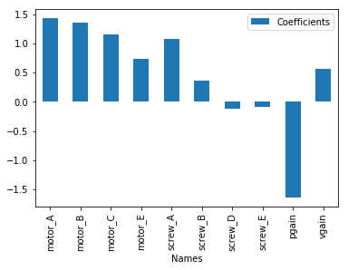

```python
# YOUR CODE HERE
coefficients = pipe_model_best.stages[1].coefficients
coefficients = np.array(coefficients)
names = ["motor_A", "motor_B", "motor_C", "motor_E", "screw_A", "screw_B", "screw_D", "screw_E", "pgain", "vgain"]

data = {'Names': names, 'Coefficients': coefficients}
df = pd.DataFrame(data = data)

print(df)

# a scatter plot comparing the coeffcients by each attribute. This helps us to see how the attribute contribute to the
# increase and decrease of rise_time

df.plot(kind='bar', x='Names')
```

When examining the coefficients, we can observe the effects of each attribute on the dependent variable. Motor_A and motor_B are the most important features for increasing rise time and pgain as well as screw_D are the most important features when decreasing rise time.